# STA5703 hw 3

Thien Pham

2023-09-21

# Preparing workspace

```r
options(
  digits = 2,   # Just gives 2 significant digits
  scipen = 999, # The larger the value the more it avoids scientific notation when printing
  warn = -1     # Suppress warnings
)
rm(
  list = ls()
)

library(magrittr)
library(ggplot2)
```

Data source: https://www.kaggle.com/datasets/raghadalharbi/all-products-available-on-sephora-website?rvi=1

This dataset contains web scraped data on products and sales from Sephora, a beauty store.

Target variable: love = The number of people that love a product.

# Loading data

```r
sephora <- readr::read_csv(
  file = "/Users/thienpham/Data Mining/data/Sephora Data.csv",
  col_types = "ccccccccccccccccccccc",
) %>%
  dplyr::select(-c(name,size,URL,MarketingFlags_content,options,details,how_to_use,ingredients))
sephora <- as.data.frame(sephora)
head(sephora)
```

```
##        id          brand  category rating number_of_reviews love price
## 1 2218774 Acqua Di Parma Fragrance    4.0                 4 3002  66.0
## 2 2044816 Acqua Di Parma   Cologne    4.5                76 2700  66.0
## 3 1417567 Acqua Di Parma   Perfume    4.5                26 2600 180.0
## 4 1417617 Acqua Di Parma   Perfume    4.5                23 2900 120.0
## 5 2218766 Acqua Di Parma Fragrance    3.5                 2  943  72.0
## 6 1417609 Acqua Di Parma   Perfume    4.5                79 2600 180.0
##   value_price MarketingFlags online_only exclusive limited_edition
## 1        75.0           True           1         0               0
## 2        66.0           True           1         0               0
## 3       180.0           True           1         0               0
## 4       120.0           True           1         0               0
## 5        80.0           True           1         0               0
## 6       180.0           True           1         0               0
##   limited_time_offer
## 1                  0
## 2                  0
## 3                  0
## 4                  0
## 5                  0
## 6                  0
```

The variables name, size, URL, MarketingFlags_content, options, details, how_to_use, and ingredients were removed because they did not contain meaningful information as of current.

# Checking levels of each variable

```r
categorical <- sephora[,c("brand", "category", "rating", "MarketingFlags")]
sapply(
  X = categorical,
  FUN = unique
)
```

```
## $brand
##   [1] "Acqua Di Parma"                   "AERIN"
##   [3] "Aether Beauty"                    "Algenist"
##   [5] "Alpha-H"                          "alpyn beauty"
##   [7] "ALTERNA Haircare"                 "amika"
##   [9] "AMOREPACIFIC"                     "Anastasia Beverly Hills"
##  [11] "Anthony"                          "Antonym"
##  [13] "Aquis"                            "Armani Beauty"
##  [15] "The Art of Shaving"               "Artis"
##  [17] "Artist Couture"                   "Atelier Cologne"
##  [19] "BALENCIAGA"                       "bareMinerals"
##  [21] "Beachwaver"                       "The Beauty Chef"
##  [23] "BeautyBio"                        "beautyblender"
##  [25] "BECCA"                            "belif"
##  [27] "Benefit Cosmetics"                "BERDOUES"
```

[output cut: 228 more lines]

No missing values were present in our categorical predictors.

# Convert numeric columns back to numbers

```r
sephora$love <- as.numeric(sephora$love)
v_numeric <- c(
  "price","value_price"
)
for(j in v_numeric) sephora[,j] <- as.numeric(
  x = sephora[,j]
)
```

# Visualizing target variable

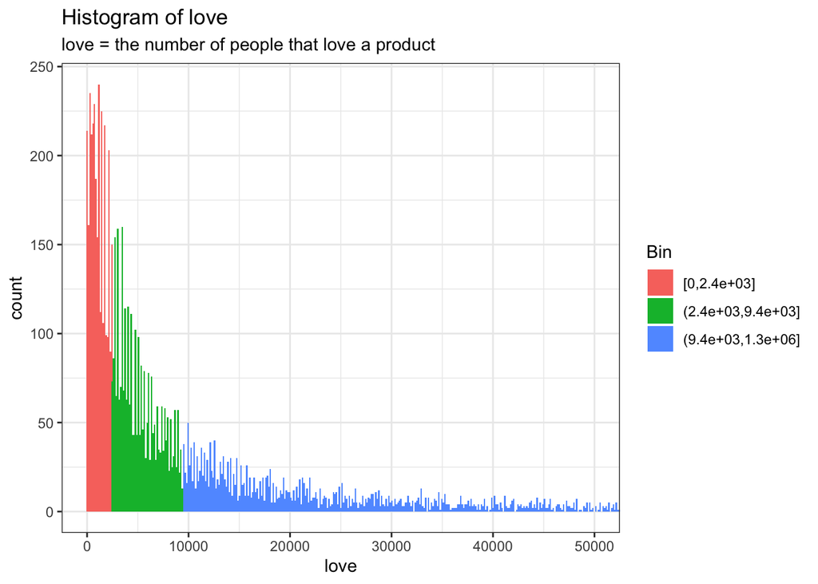

```r
sephora$Bin <- cut_number(
  x = sephora$love,
  n = 3,
  closed = "left"
)

sephora %>%
  dplyr::filter(!is.na(love)) %>%
  ggplot() +
  aes(x = love,fill = Bin) +
  geom_histogram(bins=9000) +
  theme_bw() +
  coord_cartesian(xlim = c(0,50000)) +
  labs(
    title = "Histogram of love",
    subtitle = "love = the number of people that love a product"
  )
```

As we can see, our data is heavily right skewed.

# Transforming target variable

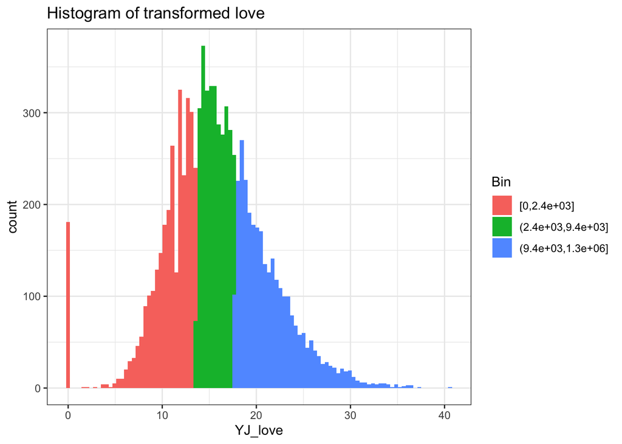

```r
# Calculates the YeoJohnson transform
preProcess_love <- caret::preProcess(
  x = sephora %>% dplyr::select(love),
  method = "YeoJohnson"
)

# Performs the YeoJohnson transform on the target variable
sephora$YJ_love <- predict(
  object= preProcess_love,
  newdata = sephora
)$love


sephora %>%
  dplyr::filter(!is.na(love)) %>%
  ggplot() +
  aes(x = YJ_love,fill = Bin) +
  geom_histogram(bins = 100) +
  theme_bw() +
  #coord_cartesian(xlim = c(0,50000))+
  labs(
    title = "Histogram of transformed love"
  )
```

Now our data is more symmetric compared to before.

# Visualize target variable by categorical predictors

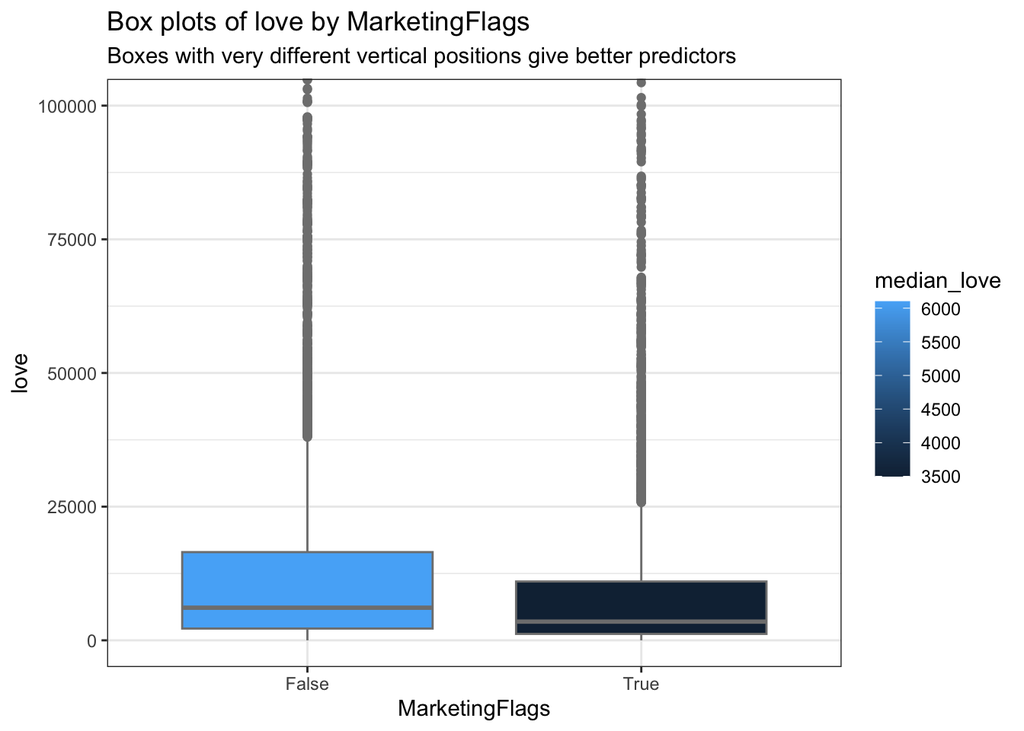

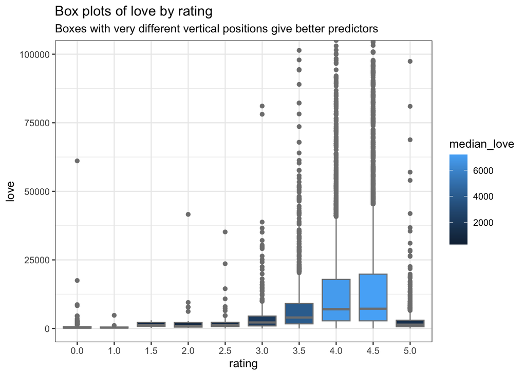

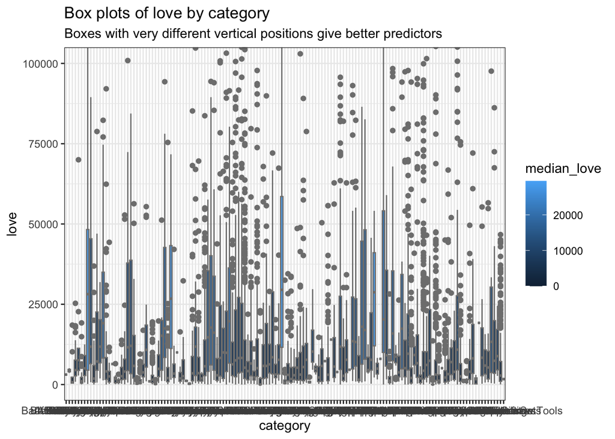

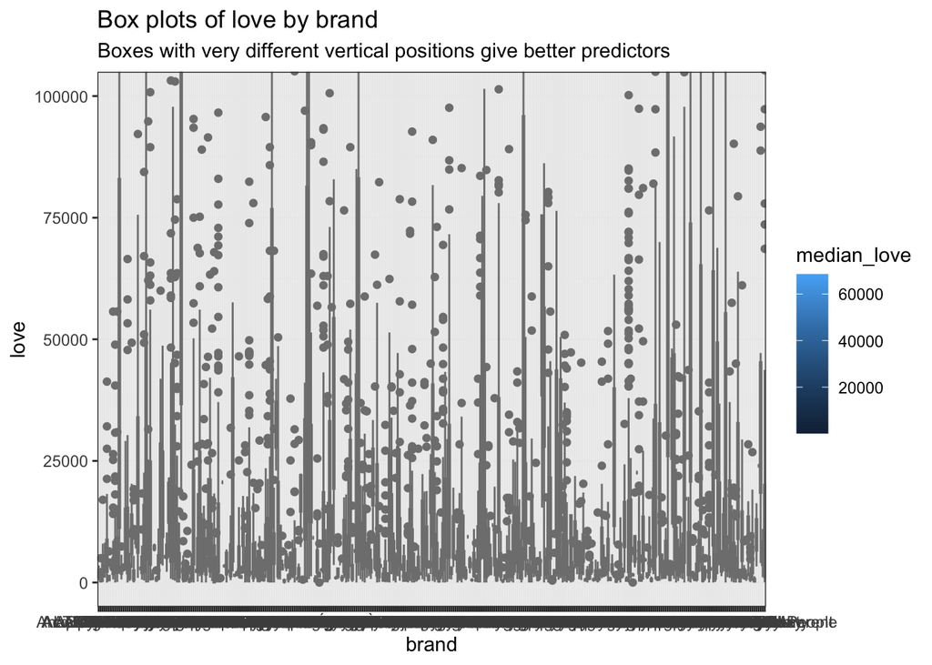

```r
v_wilcox.test <- sapply(
  X = names(categorical),
  FUN = function(j) mean(as.vector(pairwise.wilcox.test(
    x = sephora$love[!is.na(sephora$love)],
    g = sephora[!is.na(sephora$love),j]
  )$p.value),na.rm = TRUE)
)
v_wilcox.test <- sort( # Ranks the predictors by the Wilcox test's p value
  x = v_wilcox.test
)


library(ggplot2)
for(j in names(v_wilcox.test)){
  sephora_plot <- sephora[,c("love",j)] %>%
    dplyr::group_by_(j) %>%
    dplyr::mutate(median_love = median(love,na.rm = TRUE)) %>%
    dplyr::ungroup()

  p <- ggplot(sephora_plot) +
    aes_string(x = j) +
    aes(y = love,fill = median_love) +
    geom_boxplot(color = "grey50") +
    coord_cartesian(ylim = c(0, 100000)) +
    theme_bw() +
    labs(
      title = paste0("Box plots of love by ",j),
      subtitle = "Boxes with very different vertical positions give better predictors"
    )
  plot(p)
}
```

From our plots, MarkgetingFlags has the most impact followed by Rating based on Wilcoxon-signed-rank test p values. Category and Brand did not provide much information since there are so many levels.

# Capping extreme numeric values to prevents outliers from pulling model away from the rest of the data

```r
# Capping extreme values outside of the 99 percentile to the highest capped value at 99 percentile.
for(j in v_numeric){
  v_cutoffs <- quantile(
    x = sephora[,j],
    probs = c(
      0.01,0.99
    ),
    na.rm = TRUE
  )
  sephora[sephora[,j] < v_cutoffs[1] & !is.na(sephora[,j] < v_cutoffs[1]),j] <- v_cutoffs[1]
  sephora[v_cutoffs[2] < sephora[,j] & !is.na(v_cutoffs[2] < sephora[,j]),j] <- v_cutoffs[2]
}
```

# Applying Box-Cox transformation to numeric predictors

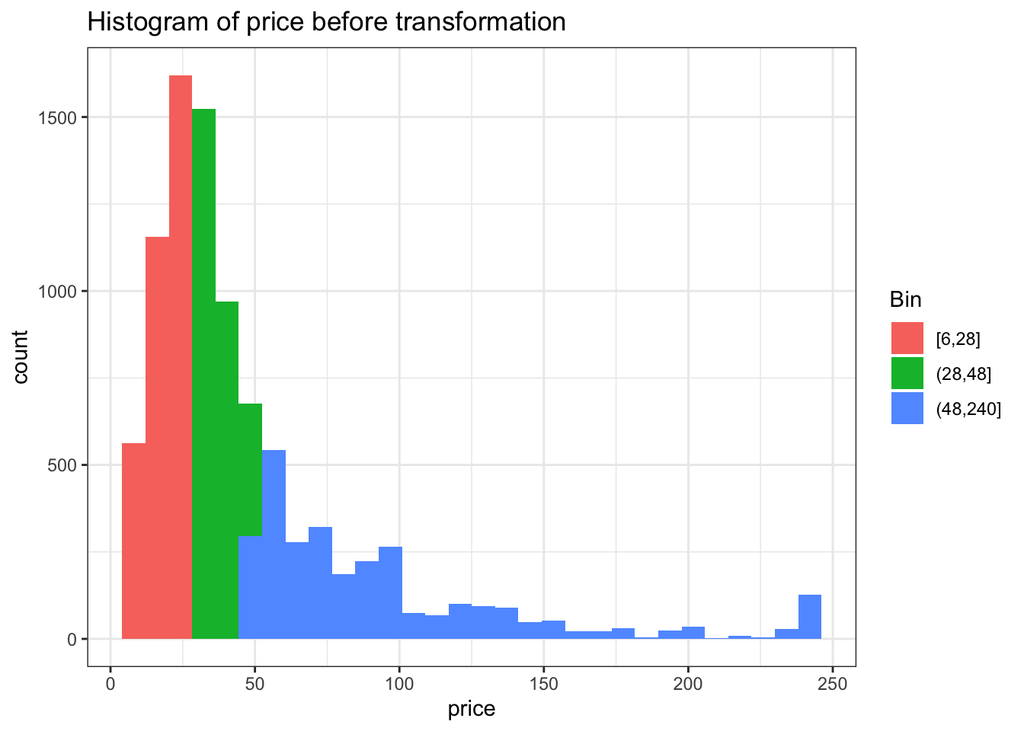

```r
sephora$Bin <- cut_number(
  x = sephora$price,
  n = 3,
  closed = "left"
)

sephora %>%
  dplyr::filter(!is.na(price)) %>%
  ggplot() +
  aes(x = price,fill = Bin) +
  geom_histogram() +
  theme_bw() +
  labs(
    title = "Histogram of price before transformation"
  )
```

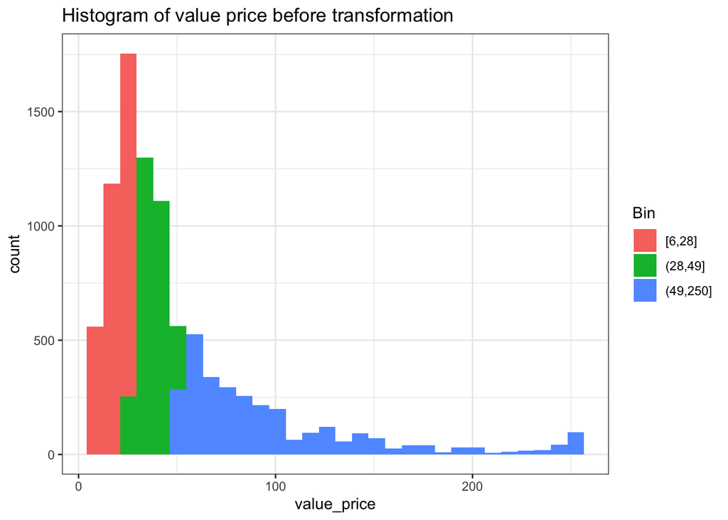

```r
sephora$Bin <- cut_number(
  x = sephora$value_price,
  n = 3,
  closed = "left"
)

sephora %>%
  dplyr::filter(!is.na(value_price)) %>%
  ggplot() +
  aes(x = value_price,fill = Bin) +
  geom_histogram() +
  theme_bw() +
  #coord_cartesian(xlim = c(0,50000)) +
  labs(
    title = "Histogram of value price before transformation"
  )
```

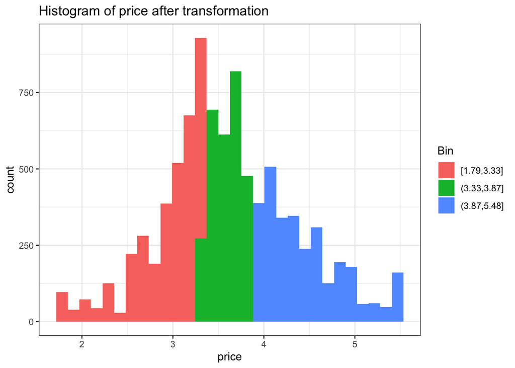

```r
v_BoxCox <- v_numeric
preProcess_BoxCox <- caret::preProcess(
  x = sephora[,v_BoxCox],
  method = "BoxCox"
)
sephora[,v_BoxCox] <- predict(
  object = preProcess_BoxCox,
  newdata = sephora[,v_BoxCox]
)

sephora$Bin <- cut_number(
  x = sephora$price,
  n = 3,
  closed = "left"
)

sephora %>%
  dplyr::filter(!is.na(price)) %>%  #dplyr::filter subsets a group under the hood for the next step
  ggplot() +
  aes(x = price,fill = Bin) +
  geom_histogram() +
  theme_bw() +
  #coord_cartesian(xlim = c(0,50000)) +
  labs(
    title = "Histogram of price after transformation"
  )
```

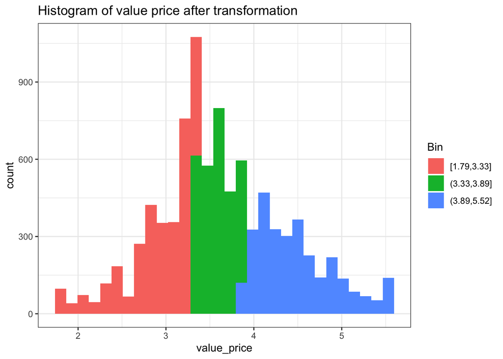

```r
sephora$Bin <- cut_number( # bin the target variable into 3 different range group for color purposes later
  x = sephora$value_price,
  n = 3,
  closed = "left"
)

sephora %>%
  dplyr::filter(!is.na(value_price)) %>%  #dplyr::filter subsets a group under the hood for the next step
  ggplot() +
  aes(x = value_price,fill = Bin) +
  geom_histogram() +
  theme_bw() +
  #coord_cartesian(xlim = c(0,50000)) +
  labs(
    title = "Histogram of value price after transformation"
  )
```

Now both of our numeric predictor variables look more normalized.

# Visualizing the target variable by numeric predictors

[figure not shown]

[figure not shown]

```r
v_cor <- sapply(
  X = v_numeric,
  FUN = function(j) cor(
    x = sephora[,j],
    y = sephora$YJ_love,
    method = "spearman",
    use = "pairwise.complete.obs"
  )
)


v_cor <- v_cor[order( # orders the correlation from largest absolute value to smallest
  x = abs(
    x = v_cor
  ),
  decreasing = TRUE
)]


for(j in names(v_cor)){
  sephora_plot <- sephora[,c("YJ_love","Bin",j)]
  p <- ggplot(sephora_plot[complete.cases(sephora_plot),]) +
    aes_string(x = j) +
    aes(y = YJ_love) +
    geom_point(aes(color = Bin)) +
    geom_smooth(color = "black",se = FALSE,method = "loess") + # loess method was used b/c linear regression was too rigid
    theme_bw() +
    labs(
      title = paste0("Scatter plot of sale price by ",j),
      subtitle = paste0("Spearman correlation: ",round(v_cor[j],2),"\nEach color has 33% of the points."),
      caption = "Data source: https://www.kaggle.com/competitions/house-prices-advanced-regression-techniques"
    )
  plot(p)
}
```

Based on the plots and spearman correlation coefficient, it appears that neither of our numeric predictors have a strong correlation to our target variable. It also appears that these 2 predictor variables might be very similar and could lead to colinearity later on.

```r
sapply(
  X = sephora,
  FUN = function(x) sum(is.na(x))
)
```

```
##                 id              brand           category             rating
##                  0                  0                  0                  0
##  number_of_reviews               love              price        value_price
##                  0                  0                  0                  0
##     MarketingFlags        online_only          exclusive    limited_edition
##                  0                  0                  0                  0
## limited_time_offer                Bin            YJ_love
##                  0                  0                  0
```

No missing values in our numeric predictor variables either.

## Binning categorical predictor variables by conditional means

```r
for(j in names(categorical)){
  M_YJ_love <- sephora %>%
    dplyr::select_(j,"YJ_love") %>%
    dplyr::mutate_(j = as.character(j)) %>%
    dplyr::group_by_(j) %>%
    dplyr::summarise(YJ_love = mean(YJ_love,na.rm = TRUE),n = dplyr::n()) %>%
    dplyr::ungroup() %>%
    dplyr::mutate(proportion = n/sum(n)) %>%
    dplyr::arrange(YJ_love) %>%
    dplyr::mutate(cumsum_ascending = cumsum(proportion)) %>%
    dplyr::arrange(dplyr::desc(cumsum_ascending)) %>%
    dplyr::mutate(cumsum_descending = 1 - cumsum(proportion)) %>%
    dplyr::arrange(cumsum_ascending) %>%
    dplyr::mutate(mean_cumsum = (cumsum_ascending + cumsum_descending)/2) %>%
    dplyr::arrange(mean_cumsum) %>%
    as.data.frame()
  v_j <- levels(M_YJ_love[,j])[M_YJ_love$mean_cumsum >= 0.5]
  sephora[,j] <- as.numeric(
    x = sephora[,j] %in% M_YJ_love[M_YJ_love$mean_cumsum >= 0.5,j]
  )
  print(
    x = "---------------------------------------------------------------------"
  )
  print(
    x = j
  )
  print(knitr::kable(
    M_YJ_love
  ))
}
```

```
## [1] "---------------------------------------------------------------------"
## [1] "brand"
##
##
## |brand                            | YJ_love|   n| proportion| cumsum_ascending| cumsum_descending| mean_cumsum|
## |:--------------------------------|-------:|---:|----------:|----------------:|-----------------:|-----------:|
## |Eight & Bob                      |     7.9|   3|       0.00|             0.00|              0.00|        0.00|
## |Overose                          |     8.1|  12|       0.00|             0.00|              0.00|        0.00|
## |Capri Blue                       |     8.2|  16|       0.00|             0.00|              0.00|        0.00|
## |Fable & Mane                     |     8.5|   5|       0.00|             0.00|              0.00|        0.00|
## |Rossano Ferretti Parma           |     8.5|  26|       0.00|             0.01|              0.00|        0.01|
## |Mizani                           |     8.8|  16|       0.00|             0.01|              0.01|        0.01|
## |WelleCo                          |     8.9|   6|       0.00|             0.01|              0.01|        0.01|
## |Lab Series For Men               |     9.2|  12|       0.00|             0.01|              0.01|        0.01|
## |Virtue                           |     9.2|  33|       0.00|             0.01|              0.01|        0.01|
## |Coal and Canary                  |     9.2|   6|       0.00|             0.01|              0.01|        0.01|
## |SKYLAR                           |     9.3|  15|       0.00|             0.02|              0.01|        0.02|
## |Floral Street                    |     9.4|  19|       0.00|             0.02|              0.02|        0.02|
## |Madam C.J. Walker Beauty Culture |     9.7|   4|       0.00|             0.02|              0.02|        0.02|
## |Seed Phytonutrients              |     9.7|  17|       0.00|             0.02|              0.02|        0.02|
## |KENZOKI                          |     9.8|  10|       0.00|             0.02|              0.02|        0.02|
## |Prima                            |     9.8|   6|       0.00|             0.02|              0.02|        0.02|
## |rag & bone                       |     9.9|   6|       0.00|             0.02|              0.02|        0.02|
## |Better Not Younger               |    10.1|  14|       0.00|             0.02|              0.02|        0.02|
## |Acqua Di Parma                   |    10.1|  35|       0.00|             0.03|              0.02|        0.03|
## |By Rosie Jane                    |    10.2|  21|       0.00|             0.03|              0.03|        0.03|
## |RODIN olio lusso                 |    10.2|   8|       0.00|             0.03|              0.03|        0.03|
## |John Varvatos                    |    10.4|   9|       0.00|             0.03|              0.03|        0.03|
## |shu uemura                       |    10.4|  45|       0.00|             0.04|              0.03|        0.04|
## |JIMMY CHOO                       |    10.5|   3|       0.00|             0.04|              0.04|        0.04|
## |goop                             |    10.5|  15|       0.00|             0.04|              0.04|        0.04|
## |Kitsch                           |    10.5|  28|       0.00|             0.04|              0.04|        0.04|
## |SOBEL SKIN Rx                    |    10.5|   8|       0.00|             0.04|              0.04|        0.04|
## |TOCCA                            |    10.5|  50|       0.01|             0.05|              0.04|        0.05|
## |Maison Louis Marie               |    10.6|  28|       0.00|             0.05|              0.05|        0.05|
## |KORRES                           |    10.6|  16|       0.00|             0.05|              0.05|        0.05|
## |Saint Jane Beauty                |    10.6|   3|       0.00|             0.05|              0.05|        0.05|
## |Etat Libre d'Orange              |    10.7|   1|       0.00|             0.05|              0.05|        0.05|
## |ELLIS BROOKLYN                   |    10.7|  29|       0.00|             0.06|              0.05|        0.06|
## |Ralph Lauren                     |    10.8|  26|       0.00|             0.06|              0.06|        0.06|
```

[output cut: 448 more lines]

```
## |2.5    |    11.6|   88|       0.01|             0.06|              0.05|        0.05|
## |2.0    |    11.7|   39|       0.00|             0.06|              0.06|        0.06|
## |5.0    |    12.1|  872|       0.10|             0.16|              0.06|        0.11|
## |3.0    |    13.4|  308|       0.03|             0.19|              0.16|        0.17|
## |3.5    |    15.1| 1051|       0.11|             0.30|              0.19|        0.25|
## |4.0    |    17.0| 2853|       0.31|             0.62|              0.30|        0.46|
## |4.5    |    17.3| 3527|       0.38|             1.00|              0.62|        0.81|
## [1] "---------------------------------------------------------------------"
## [1] "MarketingFlags"
##
##
## |MarketingFlags | YJ_love|    n| proportion| cumsum_ascending| cumsum_descending| mean_cumsum|
## |:--------------|-------:|----:|----------:|----------------:|-----------------:|-----------:|
## |True           |      15| 4382|       0.48|             0.48|              0.00|        0.24|
## |False          |      17| 4786|       0.52|             1.00|              0.48|        0.74|
```

```r
summary(
  object = sephora
)
```

```
##       id                brand         category       rating
##  Length:9168        Min.   :0.00   Min.   :0.0   Min.   :0.00
##  Class :character   1st Qu.:0.00   1st Qu.:0.0   1st Qu.:0.00
##  Mode  :character   Median :1.00   Median :1.0   Median :0.00
##                     Mean   :0.51   Mean   :0.5   Mean   :0.38
##                     3rd Qu.:1.00   3rd Qu.:1.0   3rd Qu.:1.00
##                     Max.   :1.00   Max.   :1.0   Max.   :1.00
##  number_of_reviews       love             price      value_price
##  Length:9168        Min.   :      0   Min.   :1.8   Min.   :1.8
##  Class :character   1st Qu.:   1600   1st Qu.:3.2   1st Qu.:3.2
##  Mode  :character   Median :   4800   Median :3.6   Median :3.6
##                     Mean   :  16279   Mean   :3.6   Mean   :3.6
##                     3rd Qu.:  13800   3rd Qu.:4.1   3rd Qu.:4.1
##                     Max.   :1300000   Max.   :5.5   Max.   :5.5
##  MarketingFlags online_only         exclusive         limited_edition
##  Min.   :0.00   Length:9168        Length:9168        Length:9168
##  1st Qu.:0.00   Class :character   Class :character   Class :character
##  Median :1.00   Mode  :character   Mode  :character   Mode  :character
##  Mean   :0.52
##  3rd Qu.:1.00
##  Max.   :1.00
##  limited_time_offer          Bin          YJ_love
##  Length:9168        [1.79,3.33]:3245   Min.   : 0
##  Class :character   (3.33,3.89]:2939   1st Qu.:12
##  Mode  :character   (3.89,5.52]:2984   Median :16
##                                        Mean   :16
##                                        3rd Qu.:19
##                                        Max.   :41
```